# Mode opératoire Github

Author

Franck Lequesne

Published

December 22, 2023

# Git, Git Desktop et Git Bash

[figure not shown]

## Installation et premières commandes

1. **Installation**
   - Installer **Git** (https://git-scm.com/downloads par exemple).
     - Git permettra notamment d’installer une invite de commande (**Git Bash**)
       - Remarque : plus tard, nous verrons aussi que RStudio proposera une invite de commande
   - Installer **GitHub Desktop** (https://desktop.github.com/)
     - Application “graphique” qui offre une interface utilisateur conviviale pour travailler avec Git
   - S’inscrire sur **github.com** (service web d’hébergement qui utilise le logiciel de versions Git).
2. **Quelques commandes de base pour travailler avec la console Git Bash**
   - $ **pwd** : permet de connaître le répertoire de travail actuel
   - $ **mkdir** Y permet de créer un répertoire Y
   - $ **touch** Z.txt permet de créer un fichier Z.txt
   - $ **ls** liste tous les fichiers du dossier
   - $ **cd ..** permet de remonter d’un niveau dans la hiérarchie du répertoire
3. **La configuration de Git avec Git Bash**
   - $ git config -- global --list affiche la configuration Git

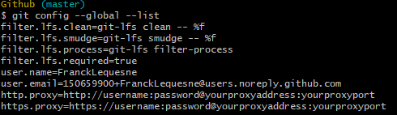

   - $ git config --global user.email mario.bros@agriculture.gouv.fr (pas besoin de guillemet)
   - $ git config --global user.name “Mario Bros”
4. **La configuration de Git avec GitHub Desktop**

   GitHub Desktop permet de définir le nom et l’adresse e-mail que l’on souhaite associer aux commits que nous effectuons dans nos dépôts. Si le nom et l’adresse ont déjà ont été définis dans la configuration Git de l’ordinateur, GitHub Desktop les détecte et utilise ces valeurs.
- A partir du menu Files/Options :

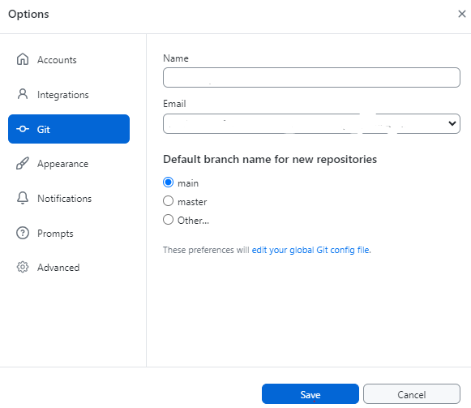

5. **Cheat sheet GitHub (en français)**

[figure not shown]

# RStudio et Git

- **Connexion RStudio et Git**
  - Dans Tools-Global Options-Git/SVN, il faut indiquer dans “Git executable” où se trouve Git
  - Il faut aussi indiquer la clé SSH (on peut créer une clé SSH depuis RStudio avec “create RSA Key”)

[figure not shown]

    - Remarque: pour récupérer la clé SSH créée sur GitHub, cliquer sur l’avatar en haut à droite:

[figure not shown]

  - Il faut enfin déclarer son identité:
    - dans le terminal RStudio (raccourci clavier, au cas où : Alt + Maj + r) avec les deux lignes de commande : *git config --global user.email “mario.bros@agriculture.gouv.fr”* et *git config --global user.name “Mario Bros”*

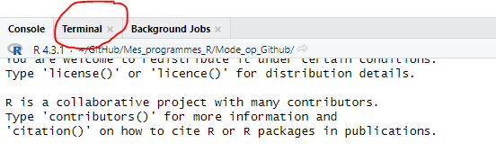

    - Déclarer le proxy dans Git :
      - Dans le terminal RStudio saisir cette première commande : *git config --global http.proxy http://rie.proxy.national.agri:8080* puis celle-ci: *git config --global https.proxy https://rie.proxy.national.agri:8080*
        - Remarques :
          - cette déclaration de proxy fonctionne aussi bien en bureau qu’en télétravail.
          - pour vérifier les paramètres, on peut toujours reprendre la commande du point 3. *: git config -- global --list qui affichera la configuration Git*

# Initialisation d’un projet R avec Git

## A partir de GitHub.com

- Sur la page d’accueil, dans le “**menu hamburger**”, créer un nouveau projet (repository) :

[figure not shown]

[figure not shown]

- Remarques :
  - Pour le nom du repository, il faut apparemment éviter les **majuscules, les espaces, les points** et le nom du repository **ne doit pas commencer par un chiffre**.
  - Dans l’idéal, ce nom doit correspondre au nom du projet R ou futur projet R (c’est déjà assez compliqué comme ça, non? )
  - Pour détruire un repository sous GitHub, il faut aller dans le menu **Settings** et en bas de page, choisir “**Delete this repository**”

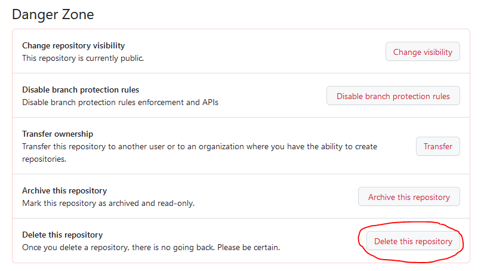

- Sur GitHub, on doit obtenir quelque chose comme ça:

[figure not shown]

- Maintenant, on doit **cloner ce repository sur Rstudio**:
  - Sur **GitHub / Code**, dans le repository créé, il faut recopier le protocole HTTPS (ou SSH) :

[figure not shown]

    - Dans RStudio, sous **File - New Project - Version Control - Git**, recopier le protocole dans le “Repository URL”, le cas échéant, choisir le répertoire qui contiendra le projet dans l’ordinateur. Project_directory_name est par défaut le nom du .git

[figure not shown]

Dans RStudio, on doit obtenir ce genre d’image :

[figure not shown]

Désormais, toutes les modifications réalisées dans le projet, sous RStudio sont “repérées” par le “Git”:

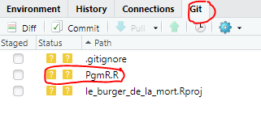

Ici, on a ajouté un fichier PgmR.R qui n’existait pas à l’initialisation du projet.

On peut **“commiter”** ce fichier :

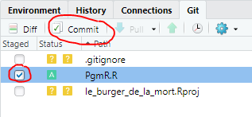

[figure not shown]

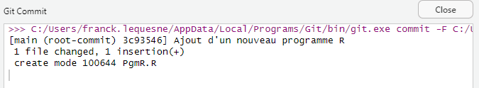

Maintenant que nous avons fait un petit travail en local, il est temps de **“pusher” notre premier “commit”** sur GitHub.

[figure not shown]

Une fenêtre va proposer une connexion à GitHub :

[figure not shown]

[figure not shown]

Ce nouveau fichier est désormais disponible sur GitHub :

[figure not shown]

## Et si le projet R existait avant la création du repository dans GitHub?

Il est apparemment recommandé d’utiliser Git dès la création d’un projet RStudio. Mais il est possible de commencer à utiliser Git d’un projet RStudio déjà existant:

- Installation et chargement du package “**usethis**”
- Dans la console, il faut exécuter l’instruction : usethis::use_git()

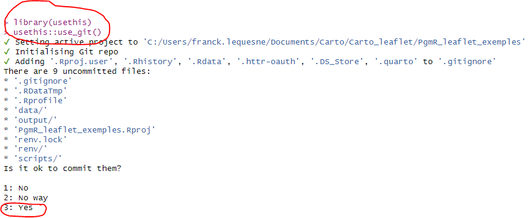

Sur GitHub, créer un nouveau repository, copier le code HTTPS.

Il suffit maintenant de **relier ce projet à Git**. Dans RStudio, sur le terminal Git, saisir :

*git remote add origin https://github.com/…git*

et

*git push -u origin master*

Vous devez obtenir dans la fenêtre Terminal, ce genre de message :

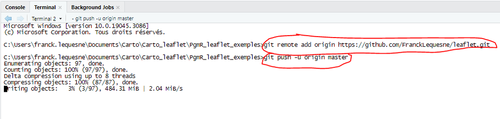

Remarque: attention, cette phase peut être assez longue…

## L’utilisation de .gitignore

RStudio a créé un fichier .gitignore au moment de l’initialisation. Certains fichiers peuvent être exclus du suivi des modifications, comme des fichiers de données (csv, xls, txt…) ou des fichiers de sortie (pdf, html…) par exemple.

Il suffit d’ouvrir le fichier .gitignore et d’ajouter le type de fichier à exclure, par exemple ici, on exclut les fichiers en csv, html:

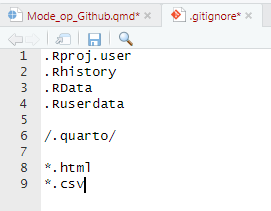

Remarque: autre solution, l’onglet Git/More/Ignore propose drectement une interface graphique pour mettre à jour ce fichier

## Comment repérer les modifications apportées au projet ?

Dans l’onglet Git, des petites icônes colorées sont positionnées à gauche du nom des fichiers

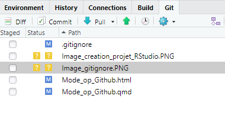

Les modifications apportées à ce fichier n’ont pas encore été prises en compte par Git

Les modifications apportées à ce fichier ont été prises en compte par Git

Les modifications de ce fichier sont suivies par Git et le fichier a été supprimé (ou éventuellement renommé) depuis la dernière fois que ses modifications ont été sauvegardées dans l’historique de Git

Un nouveau fichier est ajouté à l’historique de Git (après un push)